# Crosswalk Creation

LD

```r
# load libraries

options(scipen = 999)
library(RPostgreSQL)
library(rpostgis)
library(data.table)
library(sf)
library(dplyr)
library(foreign)
library(tidycensus)
library(data.table)

census_root <- "W:/Project/RDA Team/Census2020/data/"
cb_root <- "W:/Base/CBF/census_2018_cartographic_boundary_files/"
covidroot <- "W:/Project/RDA Team/COVID Census 2020/data/"

#loads the PostgreSQL driver
drv <- dbDriver("PostgreSQL")


# create connection
con <- dbConnect(drv, dbname = "covid19_race_class",
                 host = "aws-postgres-db.c5udgz7ro8hq.us-west-2.rds.amazonaws.com", port = 5432,
                 user = "postgres", password = "password")
```

## Load data & prepare data

#### Load COVID neighborhood data + geometries from the postgres db

Load version that is a materialized view because the view takes a very long time to load/to be queried

```r
### load covid neighborhoods from postgres db
#covid_sp <- st_read(con, "recent_lacounty_covid_case_rate_place_data_ld2")
#
# covid_sp <- st_read(con, query = "SELECT DISTINCT ON (lacounty_covid_case_rate_place_data.lac_place_name) lacounty_covid_case_rate_place_data.lac_place_name,
#     lacounty_covid_case_rate_place_data.date,
#     lacounty_covid_case_rate_place_data.confirmed_cases,
#     lacounty_covid_case_rate_place_data.cases_per100k,
#     lacounty_covid_case_rate_place_data.total_population,
#     lacounty_covid_case_rate_place_data.nh_white_pct,
#     lacounty_covid_case_rate_place_data.nh_black_pct,
#     lacounty_covid_case_rate_place_data.nh_asian_pct,
#     lacounty_covid_case_rate_place_data.latino_pct,
#     lacounty_covid_case_rate_place_data.nh_nhpi_pct,
#     lacounty_covid_case_rate_place_data.nh_aian_pct,
#     lacounty_covid_case_rate_place_data.nh_white_quantiles,
#     lacounty_covid_case_rate_place_data.nh_black_quantiles,
#     lacounty_covid_case_rate_place_data.nh_asian_quantiles,
#     lacounty_covid_case_rate_place_data.latino_quantiles,
#     lacounty_covid_case_rate_place_data.nh_aian_quantiles,
#     lacounty_covid_case_rate_place_data.nh_nhpi_quantiles,
#     lacounty_covid_case_rate_place_data.geom
#    FROM lacounty_covid_case_rate_place_data
#   WHERE lacounty_covid_case_rate_place_data.lac_place_name IS NOT NULL
#   ORDER BY lacounty_covid_case_rate_place_data.lac_place_name, lacounty_covid_case_rate_place_data.date DESC")
#


covid_sp <- st_read(con, query = "SELECT DISTINCT ON (lacounty_covid_case_rate_place_data.lac_place_name) lacounty_covid_case_rate_place_data.lac_place_name,
    lacounty_covid_case_rate_place_data.date,
    lacounty_covid_case_rate_place_data.confirmed_cases,
    lacounty_covid_case_rate_place_data.cases_per100k,
    lacounty_covid_case_rate_place_data.total_population,
    lacounty_covid_case_rate_place_data.nh_white_pct,
    lacounty_covid_case_rate_place_data.nh_black_pct,
    lacounty_covid_case_rate_place_data.nh_asian_pct,
    lacounty_covid_case_rate_place_data.latino_pct,
    lacounty_covid_case_rate_place_data.nh_nhpi_pct,
    lacounty_covid_case_rate_place_data.nh_aian_pct,
    lacounty_covid_case_rate_place_data.nh_white_quantiles,
    lacounty_covid_case_rate_place_data.nh_black_quantiles,
    lacounty_covid_case_rate_place_data.nh_asian_quantiles,
    lacounty_covid_case_rate_place_data.latino_quantiles,
    lacounty_covid_case_rate_place_data.nh_aian_quantiles,
    lacounty_covid_case_rate_place_data.nh_nhpi_quantiles,
    lacounty_covid_case_rate_place_data.geom
   FROM lacounty_covid_case_rate_place_data
  WHERE lacounty_covid_case_rate_place_data.lac_place_name IS NOT NULL
  ORDER BY lacounty_covid_case_rate_place_data.lac_place_name, lacounty_covid_case_rate_place_data.date DESC")
```

Review the data–map the geometries:

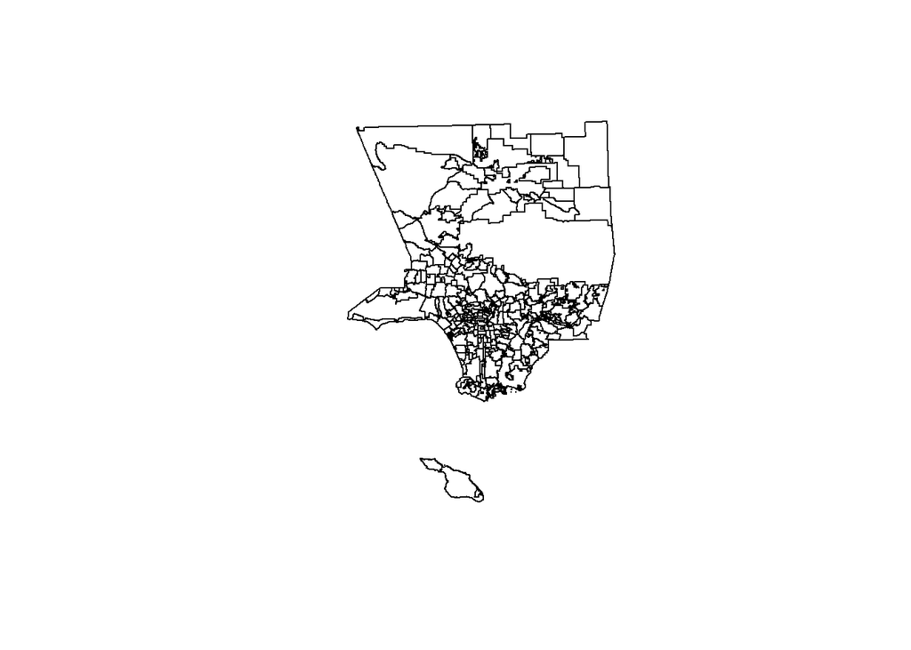

```r
# test plot
plot(covid_sp$geom)
```

Calculate area of COVID geoms

- used in eventual crosswalk

```r
# check crs
st_crs(covid_sp) # cool that's what we want
```

```
## Coordinate Reference System:
##   User input: EPSG:3310
##   wkt:
## PROJCRS["NAD83 / California Albers",
##     BASEGEOGCRS["NAD83",
##         DATUM["North American Datum 1983",
##             ELLIPSOID["GRS 1980",6378137,298.257222101,
##                 LENGTHUNIT["metre",1]]],
##         PRIMEM["Greenwich",0,
##             ANGLEUNIT["degree",0.0174532925199433]],
##         ID["EPSG",4269]],
##     CONVERSION["California Albers",
##         METHOD["Albers Equal Area",
##             ID["EPSG",9822]],
##         PARAMETER["Latitude of false origin",0,
##             ANGLEUNIT["degree",0.0174532925199433],
##             ID["EPSG",8821]],
##         PARAMETER["Longitude of false origin",-120,
##             ANGLEUNIT["degree",0.0174532925199433],
##             ID["EPSG",8822]],
##         PARAMETER["Latitude of 1st standard parallel",34,
##             ANGLEUNIT["degree",0.0174532925199433],
##             ID["EPSG",8823]],
##         PARAMETER["Latitude of 2nd standard parallel",40.5,
##             ANGLEUNIT["degree",0.0174532925199433],
##             ID["EPSG",8824]],
##         PARAMETER["Easting at false origin",0,
##             LENGTHUNIT["metre",1],
##             ID["EPSG",8826]],
##         PARAMETER["Northing at false origin",-4000000,
##             LENGTHUNIT["metre",1],
##             ID["EPSG",8827]]],
##     CS[Cartesian,2],
##         AXIS["easting (X)",east,
##             ORDER[1],
##             LENGTHUNIT["metre",1]],
##         AXIS["northing (Y)",north,
##             ORDER[2],
##             LENGTHUNIT["metre",1]],
##     USAGE[
##         SCOPE["unknown"],
##         AREA["USA - California"],
##         BBOX[32.53,-124.45,42.01,-114.12]],
##     ID["EPSG",3310]]
```

```r
# calc area of covid sp area
covid_sp$area_neighb <- st_area(covid_sp)
```

### Load self-response rate data

Load data at the tract level

```r
# get covid data date
covid_date <- max(unique(covid_sp$date))
covid_date
```

```
## [1] "2020-08-02"
```

```r
# load self response rate data tract with covid date
# dat <- fread(paste0(census_root, "self_response/selfresp_tract_converted_", covid_date, ".csv"),  data.table=FALSE, stringsAsFactors = FALSE,
#              colClasses = c("TRACTCE10" = "character", "GEOID10"="character"))

# Aug 3 is as close as it gets
dat <- fread(paste0(census_root, "self_response/selfresp_tract_converted_2020-08-03.csv"),  data.table=FALSE, stringsAsFactors = FALSE,
             colClasses = c("TRACTCE10" = "character", "GEOID10"="character"))

# query LA
dat <- dat[dat$GEOID10 %like% "06037", ]
head(dat) # review
```

```
##      TRACTCE10     GEOID10 resp_house10 resp10_house10 housecur house10
## 4194    101110 06037101110      922.488       1209.417     1596    1641
## 4195    101122 06037101122      787.512       1017.600     1256    1325
## 4198    101210 06037101210     1222.876       1444.469     2321    2150
## 4199    101220 06037101220      709.112        879.676     1294    1246
## 4200    101300 06037101300      760.550       1190.424     1435    1542
## 4201    101400 06037101400      590.673       1123.500     1473    1498
##      resp2020_converted resp2010_converted respDiff_converted access_date
## 4194          0.5780000          0.7370000         -0.1590000  2020-08-03
## 4195          0.6270000          0.7680000         -0.1410000  2020-08-03
## 4198          0.5268748          0.6718462         -0.1449714  2020-08-03
## 4199          0.5480000          0.7060000         -0.1580000  2020-08-03
## 4200          0.5300000          0.7720000         -0.2420000  2020-08-03
## 4201          0.4010000          0.7500000         -0.3490000  2020-08-03
```

### Load demographic data

- This data was grabbed from the ACS for We Count LA
  - Was already QA’d, see doc here: W:Team2020_Sheet_Report_Demographics.docx

```r
# export a version of the table with all levels combined
demog <-  fread(paste0(census_root, "convener_reports/Demographic_Language_AllLevels.csv"), stringsAsFactors = FALSE, data.table = FALSE,
                colClasses = c("GEOID"="character"))

# query tracts only
demog <- demog[demog$level =="tract",]
```

### Load tract-level HTC from the CA State Census Office

- Shapefile downloaded from SwORD. Read in the dbf of the shp.

```r
# read dbf
htc <- read.dbf(paste0(census_root, "State Census Office/CA_HTC_2020Update.dbf"))
htc$GEOID_1 <- as.character(htc$GEOID_1)

# query only LA Co, keep only columns with tract id and HTC score (data provided is all %, not raw numbers that I need to recalculate at the neighborhood level)
htc <- htc[htc$county_fip=="037", c(2, 3, 17)]
head(htc)
```

```
##      NAME     GEOID_1 CAHTCI_202
## 3 2049.20 06037204920         73
## 4 2051.10 06037205110        105
## 5 2051.20 06037205120         90
## 6 2060.10 06037206010        100
## 7 2060.20 06037206020         66
## 8 2060.50 06037206050         92
```

```r
# * Get number of vacant units
#  * Use ACS table B25005
# # load acs vars
# v18 <-  load_variables(2018, "acs5", cache = TRUE)
# # vacant B25005_001
#
# # get tract data
# vacant  <-  get_acs(geography = "tract", state="CA", county="037", variables =  "B25005_001",
#                     survey = "acs5", year=2018)
# head(vacant)
```

### Load 2010 tract geometries

```r
### Load 2010 tracts
tract10 <- st_read(paste0(cb_root, "/cb_2018_06_tract_500k/cb_2018_06_tract_500k.shp"))
# limit columns and project to SRID 3310
tract10 <- tract10[tract10$COUNTYFP =="037", c(2, 5, 6)]
tract10 <- st_transform(tract10, 3310)
```

Plot tracts (make sure things look as expected):

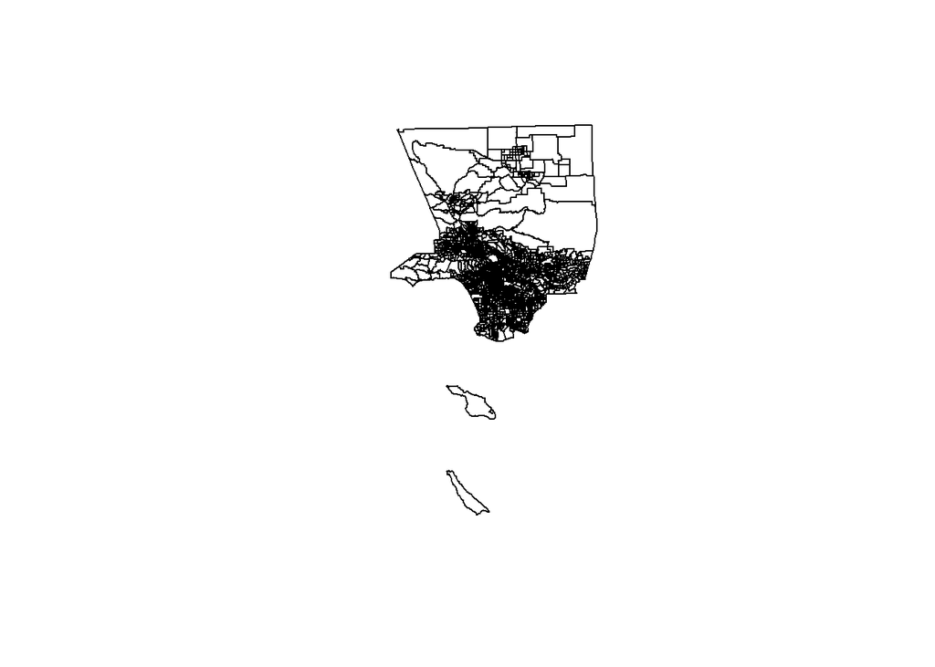

```r
plot(tract10$geometry)
```

Calculate area of tracts, to be used in crosswalk.

```r
# area of tracts
tract10$area_tract <- st_area(tract10)
```

## Create crosswalk

### Step 1. Intersect Tracts and COVID Neighborhood geometries

```r
# intersect
int <- st_intersection(st_make_valid(covid_sp), tract10)
```

### Step 2. Calculate area of intersecting polygons

```r
# calc area of intersect
int$area_int <- st_area(int)
```

### Step 3. Calculate percent overlap of intersecting area with tract

```r
# % intersect
int$prc_int <- as.numeric(int$area_int/int$area_tract)
```

```r
# just look at one tract and some columns
int[int$GEOID =="06037216200", c(1:4, 19:25)]
```

```
## Simple feature collection with 4 features and 10 fields
## geometry type:  GEOMETRY
## dimension:      XY
## bbox:           xmin: 151885 ymin: -439131.7 xmax: 153116.4 ymax: -437931.3
## projected CRS:  NAD83 / California Albers
##         lac_place_name       date confirmed_cases cases_per100k COUNTYFP
## 75.10     Hancock Park 2020-08-02             173      1015.318      037
## 125.7         Mid-city 2020-08-02             235      1563.540      037
## 126.12    Miracle Mile 2020-08-02             127       706.144      037
## 184.2  Sycamore Square 2020-08-02               4            NA      037
##              GEOID NAME     area_tract                           geom
## 75.10  06037216200 2162 953705.2 [m^2] MULTIPOLYGON (((153116.4 -4...
## 125.7  06037216200 2162 953705.2 [m^2] MULTIPOLYGON (((152146.3 -4...
## 126.12 06037216200 2162 953705.2 [m^2] MULTIPOLYGON (((152905.2 -4...
## 184.2  06037216200 2162 953705.2 [m^2] POLYGON ((153116.1 -438122....
##                     area_int          prc_int
## 75.10       0.08965227 [m^2] 0.00000009400417
## 125.7     524.41619881 [m^2] 0.00054987243842
## 126.12 788536.40207136 [m^2] 0.82681357893399
## 184.2  164644.28289943 [m^2] 0.17263645462341
```

- We’ve got one tract intersecting 4 neighborhood polygons
- Looks like there is one neighborhood with ~82% of the tract area, one neighborhood with ~17% of the tract area.

#### Map this one tract and the surrounding neighborhoods:

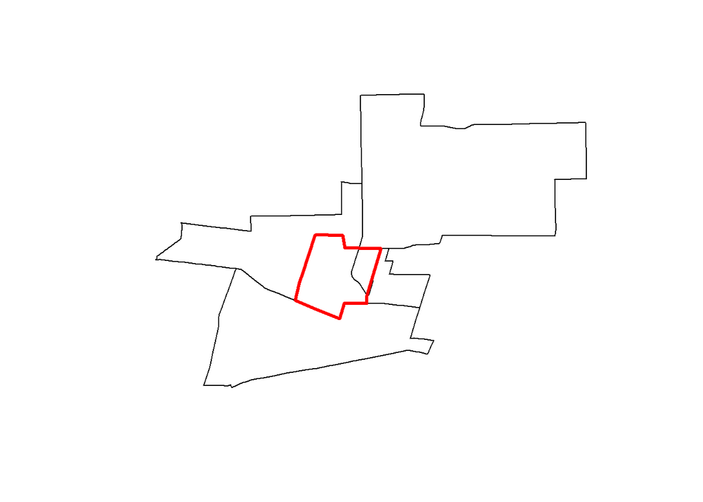

```r
plot(covid_sp[covid_sp$lac_place_name %in% c("Miracle Mile", "Mid-city", "Hancock Park",
                                             "Sycamore Square"),]$geom)
plot(tract10[tract10$GEOID=="06037216200",]$geometry, border="red", lwd=3, add=T)
```

- Yes looks like the other two neighborhoods are only slivers / not important intersects.

### Step 4. Dissolve on Neighborhood Name/Tract ID

- Try to dissolve any multipolygon slivers.
- Sum area of intersect and keep tract and neighborhood area the same.
- Recalculate percentage of intersect

```r
# dissolve on place name/tract ids to capture any slivers
int_dissolve <-
  int %>%
  as.data.frame() %>%
  group_by(lac_place_name, GEOID, NAME ) %>%
  summarize(area_int = sum(area_int, na.rm = T),
            area_tract = mean(area_tract, na.rm = T),
            area_neighb = mean(area_neighb, na.rm = T)) %>%
  mutate(prc_int = area_int/area_tract) %>%
  as.data.frame() %>%
  mutate(GEOID = as.character(GEOID))
```

### Step 5. Export crosswalk file here:

```r
write.csv(int_dissolve, paste0(covidroot, "lac_place_tract_xwalk.csv"), row.names = FALSE)
```

## Proportional Allocation of Tract Population

### Step 1. Join data to crosswalk

- Join response rate data to the tract/neighborhood crosswalk

```r
# join tracts to neighborhood crosswalk
xwalk <- full_join(dat, int_dissolve,
                   by= c("GEOID10"= "GEOID")) #%>%
  # left_join(vacant, by=c("GEOID10" = "GEOID"))
```

- Review by checking on our fave tract:

```r
subset(xwalk, GEOID10=="06037216200")
```

```
##      TRACTCE10     GEOID10 resp_house10 resp10_house10 housecur house10
## 1519    216200 06037216200     1464.871       1662.672     2669    2475
## 1520    216200 06037216200     1464.871       1662.672     2669    2475
## 1521    216200 06037216200     1464.871       1662.672     2669    2475
## 1522    216200 06037216200     1464.871       1662.672     2669    2475
##      resp2020_converted resp2010_converted respDiff_converted access_date
## 1519          0.5488465          0.6717865           -0.12294  2020-08-03
## 1520          0.5488465          0.6717865           -0.12294  2020-08-03
## 1521          0.5488465          0.6717865           -0.12294  2020-08-03
## 1522          0.5488465          0.6717865           -0.12294  2020-08-03
##       lac_place_name NAME              area_int     area_tract
## 1519    Hancock Park 2162      0.08965227 [m^2] 953705.2 [m^2]
## 1520        Mid-city 2162    524.41619881 [m^2] 953705.2 [m^2]
## 1521    Miracle Mile 2162 788536.40207136 [m^2] 953705.2 [m^2]
## 1522 Sycamore Square 2162 164644.28289943 [m^2] 953705.2 [m^2]
##          area_neighb          prc_int
## 1519 5325585.0 [m^2] 0.00000009400417
## 1520 2911421.5 [m^2] 0.00054987243842
## 1521 3089830.4 [m^2] 0.82681357893399
## 1522  170130.9 [m^2] 0.17263645462341
```

**HTC** * Join the HTC tract data to the crosswalk in a separate DF  
* It doesn’t make sense/we can’t use proportional allocation for HTC score, so use a different method to get HTC estimate to neighborhood  
* Assign the tract to the neighborhood it most intersects

```r
xwalk_htc_join <-
  int_dissolve %>%
  left_join(htc %>% select(-NAME), by=c("GEOID" = "GEOID_1")) %>%
  mutate(NAME = as.character(NAME)) %>%
  select(-c(area_int, area_tract, area_neighb))
```

- Review by checking on our fave tract:

```r
subset(xwalk_htc_join, GEOID=="06037216200")
```

```
##       lac_place_name       GEOID NAME          prc_int CAHTCI_202
## 1419    Hancock Park 06037216200 2162 0.00000009400417         44
## 2496        Mid-city 06037216200 2162 0.00054987243842         44
## 2519    Miracle Mile 06037216200 2162 0.82681357893399         44
## 3839 Sycamore Square 06037216200 2162 0.17263645462341         44
```

- Because Miracle Mile is the neighborhood this tract most intersects with, we want to make sure this tract goes to that neighborhood.

Get the maximum percent intersect by tract ID:

```r
# select the neighborhood that the tract most represents. this is to prevent intersect sliver from contributing to the mean HTC score
xwalk_htc <-
  xwalk_htc_join %>%
  as.data.frame() %>%
  group_by(GEOID, NAME) %>%
  slice( which.max(prc_int) )

    # this takes the neighborhoods that don't have any tracts primarily contributing to them (i.e. Brookside) and selects the most representative tract.
    # this means a tract will represent more than one neghborhood, but enables us to get a mean htc score for every neighborhood

xwalk_htc_partial <-
xwalk_htc_join %>%
  as.data.frame() %>%
  filter(!lac_place_name %in% xwalk_htc$lac_place_name) %>%
  group_by(lac_place_name) %>%
  slice( which.max(prc_int) )


# review number of neighborhoods
length(unique(xwalk_htc_join$lac_place_name)) # 332 neighborhoods at the start
```

```
## [1] 332
```

```r
length(unique(xwalk_htc$lac_place_name))  # drops 32 neighborhoods without a primary tract rep
```

```
## [1] 300
```

```r
length(unique(xwalk_htc_partial$lac_place_name)) # this will add those 32 back in
```

```
## [1] 32
```

Review Brookside test case

- only 3 tracts intersect the Brookside neighborhood, two are really just slivers, and one (2161) contributes 39% of its area to the neighborhood.

```r
# also test this small neighborhood and watch how it progresses through the crosswalk
subset(xwalk_htc_join, lac_place_name =="Brookside")
```

```
##     lac_place_name       GEOID    NAME        prc_int CAHTCI_202
## 416      Brookside 06037211000    2110 0.000266511620         26
## 417      Brookside 06037212702 2127.02 0.000001510087         44
## 418      Brookside 06037216100    2161 0.388733942675         20
```

```r
subset(xwalk_htc, lac_place_name =="Brookside") # brooksides biggest tract intersect goes to a different neighborhood
```

```
## # A tibble: 0 x 5
## # Groups:   GEOID, NAME [0]
## # ... with 5 variables: lac_place_name <chr>, GEOID <chr>, NAME <chr>,
## #   prc_int <dbl>, CAHTCI_202 <dbl>
```

```r
subset(xwalk_htc_partial, lac_place_name =="Brookside")
```

```
## # A tibble: 1 x 5
## # Groups:   lac_place_name [1]
##   lac_place_name GEOID       NAME  prc_int CAHTCI_202
##   <chr>          <chr>       <chr>   <dbl>      <dbl>
## 1 Brookside      06037216100 2161    0.389         20
```

Bind the data frames together

```r
xwalk_htc <- bind_rows(xwalk_htc, xwalk_htc_partial)
```

```r
subset(xwalk_htc, GEOID=="06037216200")
```

```
## # A tibble: 2 x 5
## # Groups:   GEOID, NAME [1]
##   lac_place_name  GEOID       NAME  prc_int CAHTCI_202
##   <chr>           <chr>       <chr>   <dbl>      <dbl>
## 1 Miracle Mile    06037216200 2162    0.827         44
## 2 Sycamore Square 06037216200 2162    0.173         44
```

### Step 2. Summarize by COVID Neighborhood

- Multiply the percent intersect by:
  - the number of households that responded
  - the total number of households
- Group by neighborhood name
- Sum proportional number of responding households, total number of households
  - divide to get the response rate by neighborhood

```r
## sumamrize by neighborhood
xwalk_summary <-
xwalk %>%

  # multiply households by % neighborhood
  mutate(resp_hh_conv = resp_house10 * prc_int,
         tot_hh_conv = housecur * prc_int) %>%

  # group by neighborhood
  group_by(lac_place_name) %>%

  summarize(
          # sum number of responding households, total households
            resp_conv = sum(resp_hh_conv, na.rm=T),
            tot_conv = sum(tot_hh_conv, na.rm = T),

          # calculate neighborhood response rate by dividng responding hh by total hh
            prc = resp_conv/tot_conv)


head(xwalk_summary)
```

```
## # A tibble: 6 x 4
##   lac_place_name          resp_conv tot_conv   prc
##   <chr>                       <dbl>    <dbl> <dbl>
## 1 Adams-Normandie           1193.     2382.  0.501
## 2 Agoura Hills              5135.     6795.  0.756
## 3 Alhambra                 20781.    29429.  0.706
## 4 Alsace                    1679.     3416.  0.491
## 5 Angeles National Forest      4.88     15.5 0.316
## 6 Angelino Heights           432.      914.  0.473
```

#### Summarize HTC

- Group by place name
- Summarize
  - get mean of HTC index in the neighborhood

```r
xwalk_htc_mean <-
  xwalk_htc %>%
  group_by(lac_place_name) %>%
  summarize(mean_htc = mean(CAHTCI_202, na.rm = T))

head(xwalk_htc_mean)
```

```
## # A tibble: 6 x 2
##   lac_place_name          mean_htc
##   <chr>                      <dbl>
## 1 Adams-Normandie             81
## 2 Agoura Hills                10.3
## 3 Alhambra                    52.9
## 4 Alsace                      69.7
## 5 Angeles National Forest     10
## 6 Angelino Heights            53
```

```r
summary(xwalk_htc_mean)
```

```
##  lac_place_name        mean_htc
##  Length:332         Min.   :  1.00
##  Class :character   1st Qu.: 24.62
##  Mode  :character   Median : 41.42
##                     Mean   : 44.44
##                     3rd Qu.: 62.39
##                     Max.   :112.00
```

## Finalize Data

### Join COVID spatial to Summaries

- Join covid geometries to the household/census summary
- Join the HTC mean estimate
- Remove records where place name is null or where cases per 100k people is null (these are places where total population was less than 1,000)

```r
covid_resp <-
covid_sp %>%
  full_join(xwalk_summary, by="lac_place_name") %>%
  full_join(xwalk_htc_mean, by="lac_place_name") %>%
  filter(!is.na(lac_place_name) & !is.na(cases_per100k))
```

### Export Data

Make an object with the date of the response rate data:

```r
data_date <- unique(dat$access_date)[1]
data_date <- gsub("-", "_", data_date)
data_date
```

```
## [1] "2020_08_03"
```

```r
# EXPORT spatial files
st_write(covid_resp, paste0(covidroot, "covid_dem_resp_", data_date, ".shp"), driver = "ESRI Shapefile", delete_dsn = TRUE)
```

```
## Deleting source `W:/Project/RDA Team/COVID Census 2020/data/covid_dem_resp_2020_08_03.shp' using driver `ESRI Shapefile'
## Writing layer `covid_dem_resp_2020_08_03' to data source `W:/Project/RDA Team/COVID Census 2020/data/covid_dem_resp_2020_08_03.shp' using driver `ESRI Shapefile'
## Writing 302 features with 22 fields and geometry type Unknown (any).
```

```r
st_write(covid_resp, paste0(covidroot, "covid_dem_resp.shp"), driver = "ESRI Shapefile", delete_dsn = TRUE)
```

```
## Deleting source `W:/Project/RDA Team/COVID Census 2020/data/covid_dem_resp.shp' using driver `ESRI Shapefile'
## Writing layer `covid_dem_resp' to data source `W:/Project/RDA Team/COVID Census 2020/data/covid_dem_resp.shp' using driver `ESRI Shapefile'
## Writing 302 features with 22 fields and geometry type Unknown (any).
```

```r
st_write(covid_resp, paste0(covidroot, "covid_dem_resp_", data_date, ".geojson"), driver = "GeoJSON", delete_dsn = TRUE)
```

```
## Deleting source `W:/Project/RDA Team/COVID Census 2020/data/covid_dem_resp_2020_08_03.geojson' using driver `GeoJSON'
## Writing layer `covid_dem_resp_2020_08_03' to data source `W:/Project/RDA Team/COVID Census 2020/data/covid_dem_resp_2020_08_03.geojson' using driver `GeoJSON'
## Writing 302 features with 22 fields and geometry type Unknown (any).
```

```r
st_write(covid_resp, paste0(covidroot, "covid_dem_resp.geojson"), driver = "GeoJSON", delete_dsn = TRUE)
```

```
## Deleting source `W:/Project/RDA Team/COVID Census 2020/data/covid_dem_resp.geojson' using driver `GeoJSON'
## Writing layer `covid_dem_resp' to data source `W:/Project/RDA Team/COVID Census 2020/data/covid_dem_resp.geojson' using driver `GeoJSON'
## Writing 302 features with 22 fields and geometry type Unknown (any).
```

```r
# Export csv
covid_resp_df <- covid_resp %>% as.data.frame() %>% select(-geom)
write.csv(covid_resp_df, paste0(covidroot, "covid_dem_resp_", data_date, ".csv"), row.names = FALSE)
write.csv(covid_resp_df, paste0(covidroot, "covid_dem_resp.csv"), row.names = FALSE)


# Write data to postgres db
# create connection
# con2 <- dbConnect(drv, dbname = "covid_census2020",
#                  host = "aws-postgres-db.c5udgz7ro8hq.us-west-2.rds.amazonaws.com", port = 5432,
#                  user = "postgres", password = "password")


#st_write(obj = covid_resp, dsn = con2, layer =  paste0("covid_dem_response_", data_date), delete_layer = TRUE, delete_dsn = TRUE)



# write comment to table
# add  data date to table name /comment
#sql_command <- "COMMENT ON TABLE covid_dem_response_2020_05_04 IS 'COVID-19 cases (as of 05/04/20) with Census 2020 response rates (as of 05/04/20) and some demographic information. Using recent_lacounty_covid_case_rate_place_data_ld2 (materialized view in the covid19_race_class db), crosswalk census tracts to COVID neighborhoods using geographic proportional allocation and estimate census response rates for these neighborhoods. Estimate mean HTC tract score for neighborhood. See R script methods_xwalk.Rmd.'"

# send comment to database
#dbGetQuery(con2, sql_command)
```